# Predictive Modeling & Forecasting Summary

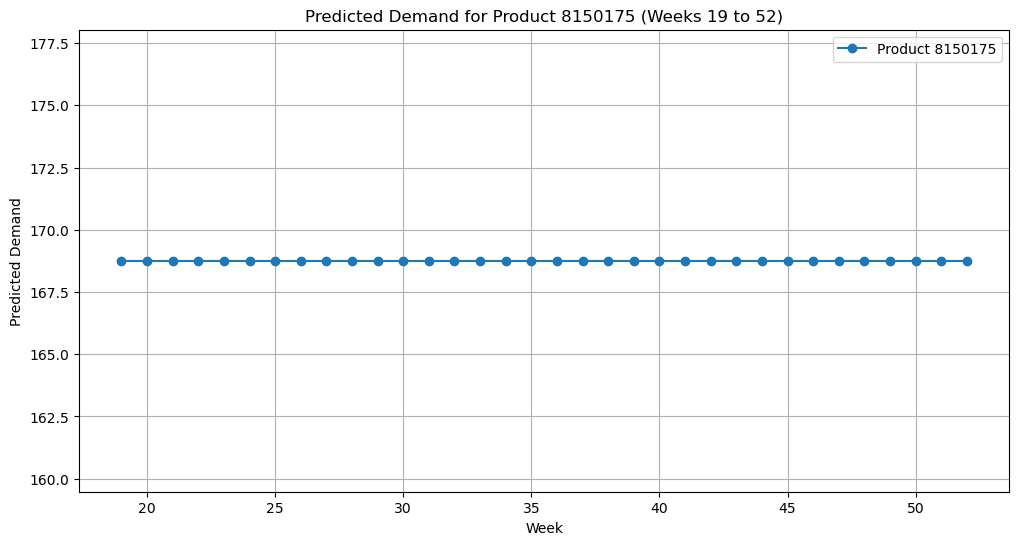

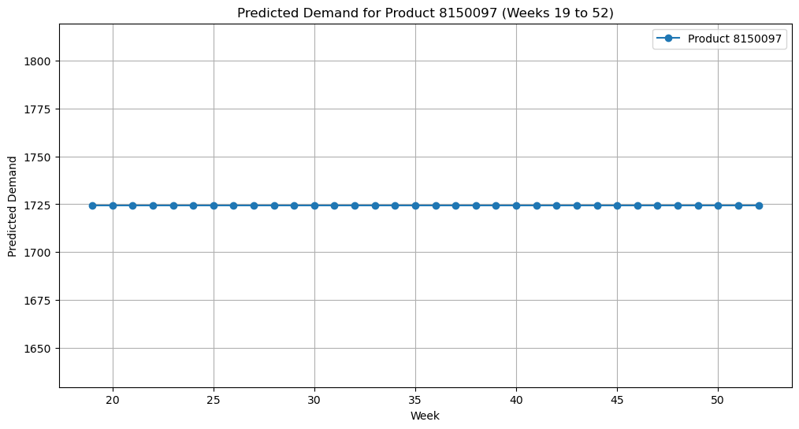

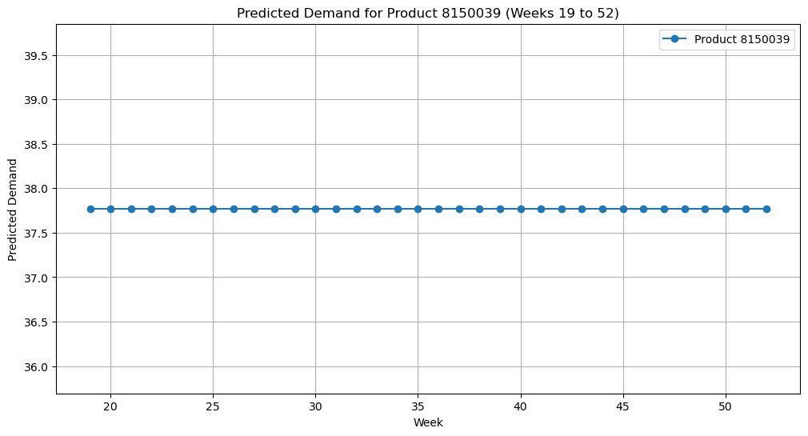

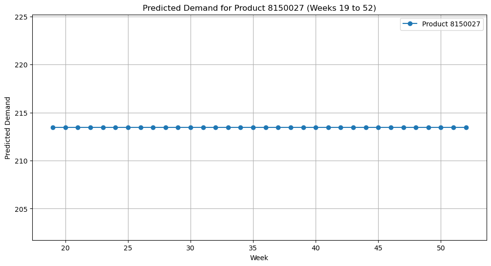

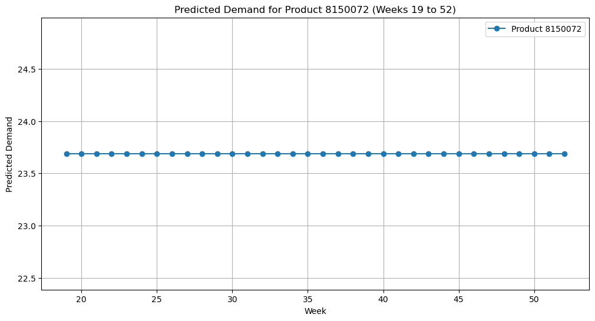

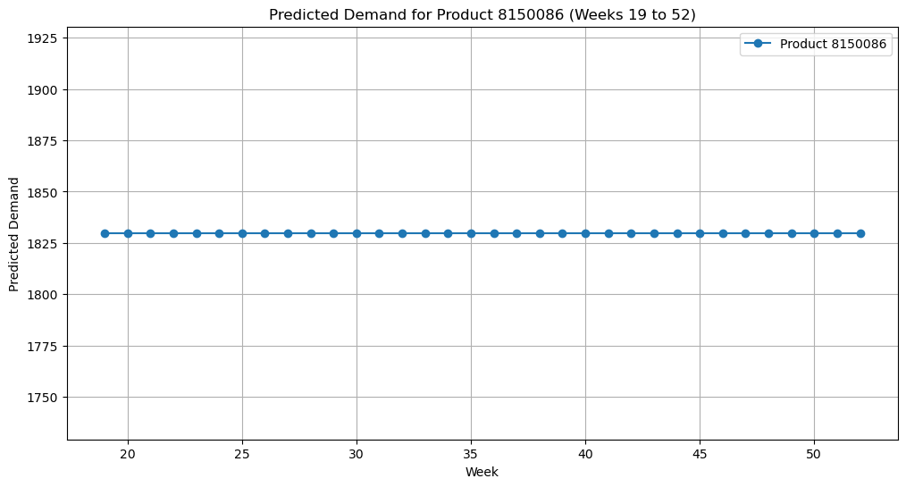

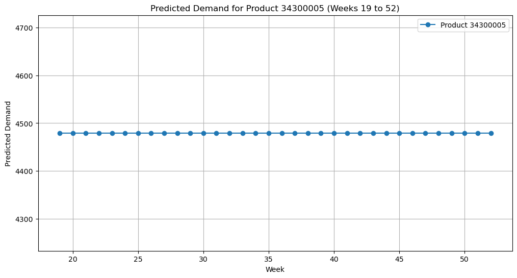

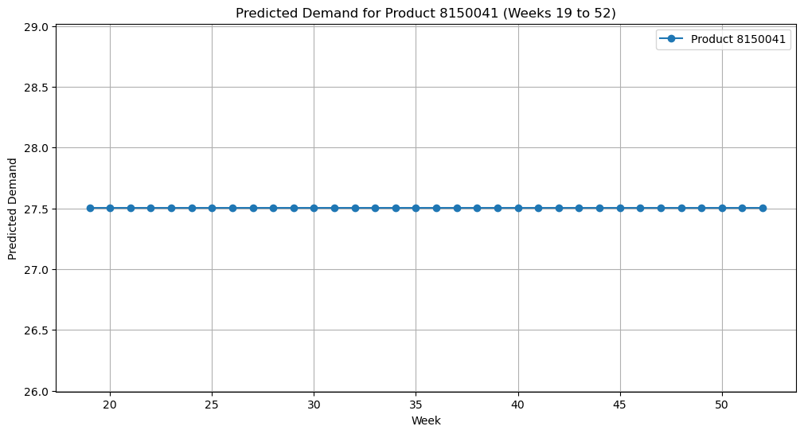

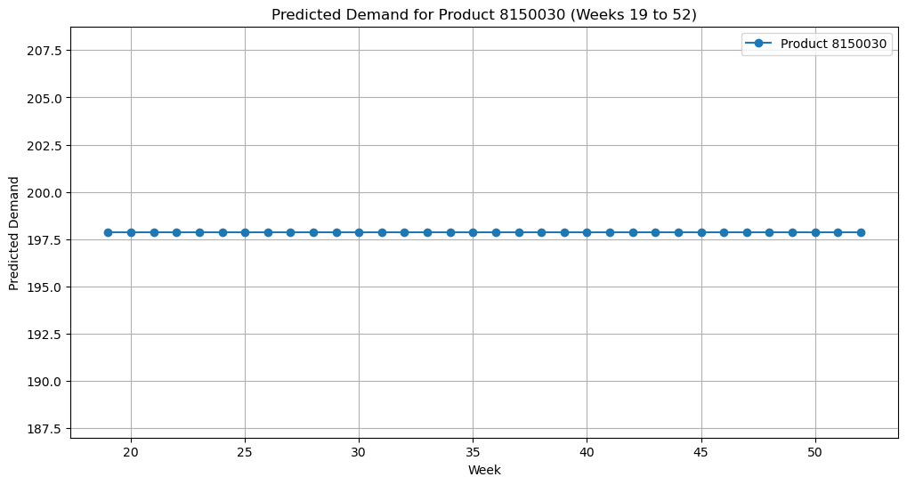

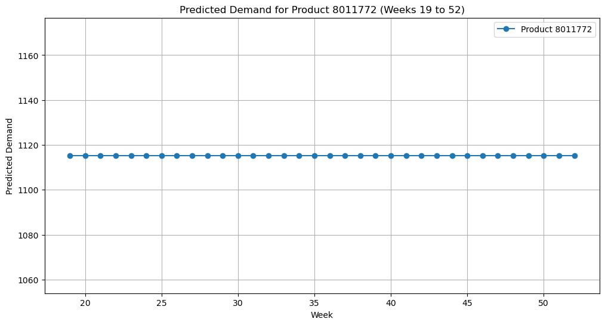

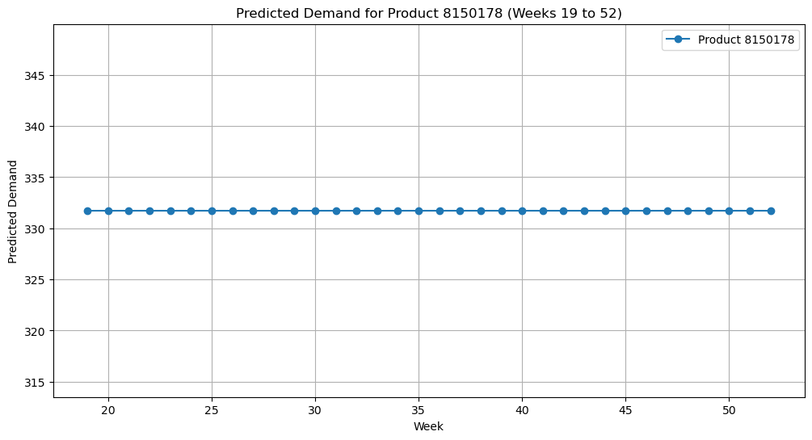

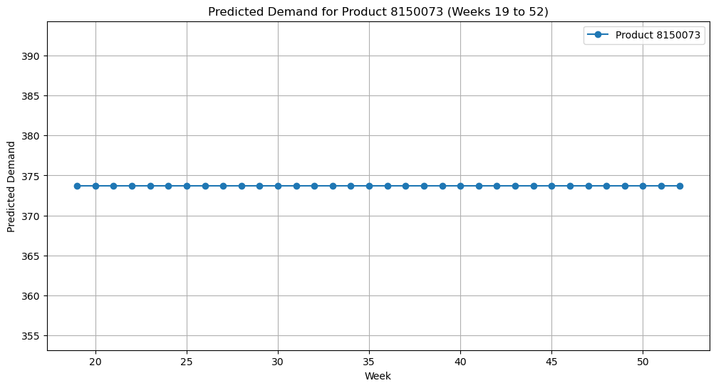

[16 more figures not shown]

```python
import matplotlib.pyplot as plt

# Plot predicted demand for each product as a line graph
for product_id in top_10_corp_item_cd:
    product_data = future_predictions[future_predictions['corp_item_cd'] == product_id]

    plt.figure(figsize=(12, 6))
    plt.plot(product_data['Week'], product_data['Predicted_Demand'], marker='o', linestyle='-', label=f'Product {product_id}')
    plt.title(f'Predicted Demand for Product {product_id} (Weeks 19 to 52)')
    plt.xlabel('Week')
    plt.ylabel('Predicted Demand')
    plt.legend()
    plt.grid(True)
    plt.show()
```

```python
import numpy as np

# Generate future weeks (19 to 52) for prediction
future_weeks = np.arange(19, 53)

# Prepare a list to store predictions
predictions_list = []

# Get the feature columns used in training (the same columns used in X_train)
feature_columns = X_train.columns  # This is critical - ensures compatibility

for product_id in top_10_corp_item_cd:
    # Filter data for the specific product
    product_data = filtered_df[filtered_df['corp_item_cd'] == product_id]

    # Use historical features for prediction
    X_future = product_data.drop(['valid_demand_qty', 'week_dem', 'year_dem'], axis=1).iloc[-1:]  # Using last known data point for prediction

    # Keep only the columns used for training
    X_future = X_future[feature_columns]  # Ensuring compatibility with trained model

    for week in future_weeks:
        # Add columns for 'week_dem' and 'year_dem' if needed for context (not used in prediction)
        X_future['week_dem'] = week
        X_future['year_dem'] = 2025

        # Ensure only columns used during training are passed to the model
        X_future_for_model = X_future[feature_columns]

        # Make prediction using the trained stacking model
        predicted_demand = stacking_model.predict(X_future_for_model)[0]

        # Add the prediction to the list
        predictions_list.append({
            'corp_item_cd': product_id,
            'Week': week,
            'Predicted_Demand': predicted_demand
        })

# Convert the list to a DataFrame
future_predictions = pd.DataFrame(predictions_list)

# Display the predictions
print(future_predictions)
```

```
     corp_item_cd  Week  Predicted_Demand
0         8150175    19        168.757879
1         8150175    20        168.757879
2         8150175    21        168.757879
3         8150175    22        168.757879
4         8150175    23        168.757879
..            ...   ...               ...
947       8200084    48        515.444081
948       8200084    49        515.444081
949       8200084    50        515.444081
950       8200084    51        515.444081
951       8200084    52        515.444081

[952 rows x 3 columns]
```

```python
# Adding 'week_dem' and 'year_dem' to the training data
X_train = filtered_df[['week_dem', 'year_dem'] + [col for col in filtered_df.columns if col not in ['valid_demand_qty', 'corp_item_cd']]]
y_train = filtered_df['valid_demand_qty']

# Split data into training and testing sets
from sklearn.model_selection import train_test_split
X_train, X_test, y_train, y_test = train_test_split(X_train, y_train, test_size=0.2, random_state=42)
```

```python
import numpy as np
import pandas as pd

# Generate future weeks (19 to 52)
future_weeks = np.arange(19, 53)

# Prepare a list to store predictions
predictions_list = []

# Get the feature columns used during training
feature_columns = X_train_encoded.columns  # The columns used for training

# Make sure the encoder is applied to categorical features
def encode_features(data, label_encoders):
    data_copy = data.copy()
    for col, le in label_encoders.items():
        if col in data_copy.columns:
            data_copy[col] = le.transform(data_copy[col].astype(str))
    return data_copy

# Iterate over each top 10 product ID
for product_id in top_10_corp_item_cd:
    # Filter the original data for the specific product
    product_data = filtered_df[filtered_df['corp_item_cd'] == product_id]

    # Use the last known data point for this product for initialization
    X_future = product_data.iloc[-1:].copy()

    # Encode categorical features using the label encoders created during training
    X_future = encode_features(X_future, label_encoders)

    # Keep only the columns used for training
    X_future = X_future[feature_columns].copy()

    # Add 'year_dem' for prediction purposes
    X_future['year_dem'] = 2025

    # Iterate over weeks 19 to 52
    for week in future_weeks:
        X_future['week_dem'] = week  # Update the week column for prediction

        # Ensure only columns used during training are passed to the model
        X_future_for_model = X_future[feature_columns]

        # Predict demand for the current week
        predicted_demand = stacking_model.predict(X_future_for_model)[0]

        # Add prediction to the list
        predictions_list.append({
            'corp_item_cd': product_id,
            'Week': week,
            'Predicted_Demand': predicted_demand
        })

        # **Dynamic Feature Update**
        # Update the 'valid_demand_qty' (or the relevant feature) for the next prediction
        X_future['valid_demand_qty'] = predicted_demand

# Convert predictions list to a DataFrame
future_predictions = pd.DataFrame(predictions_list)

# Display the predictions
print(future_predictions)
```

```
     corp_item_cd  Week  Predicted_Demand
0         8150175    19        147.581637
1         8150175    20        147.581637
2         8150175    21        148.606235
3         8150175    22        154.703834
4         8150175    23        151.693580
..            ...   ...               ...
947       8200084    48        512.480840
948       8200084    49        512.118813
949       8200084    50        512.224717
950       8200084    51        512.224717
951       8200084    52        511.320107

[952 rows x 3 columns]
```

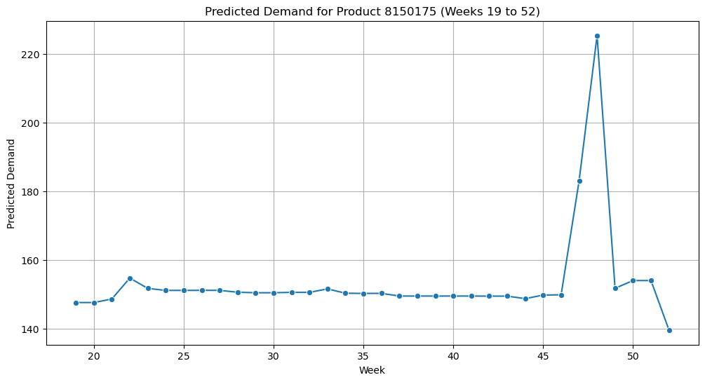

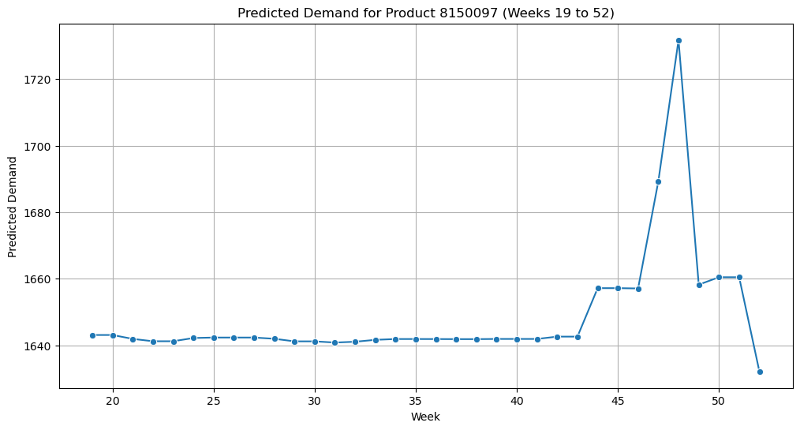

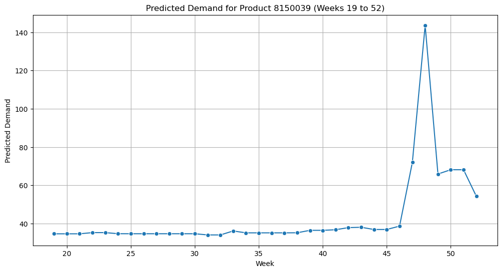

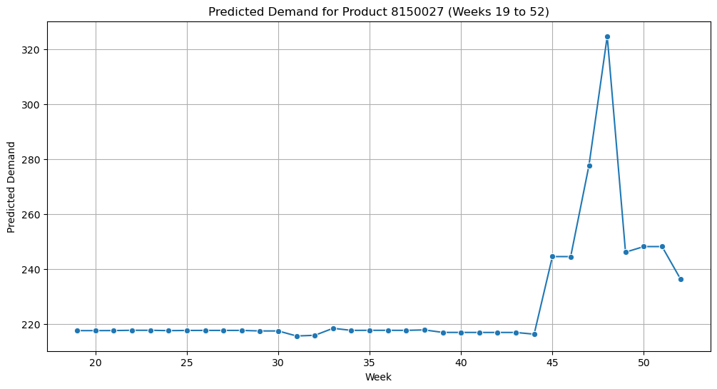

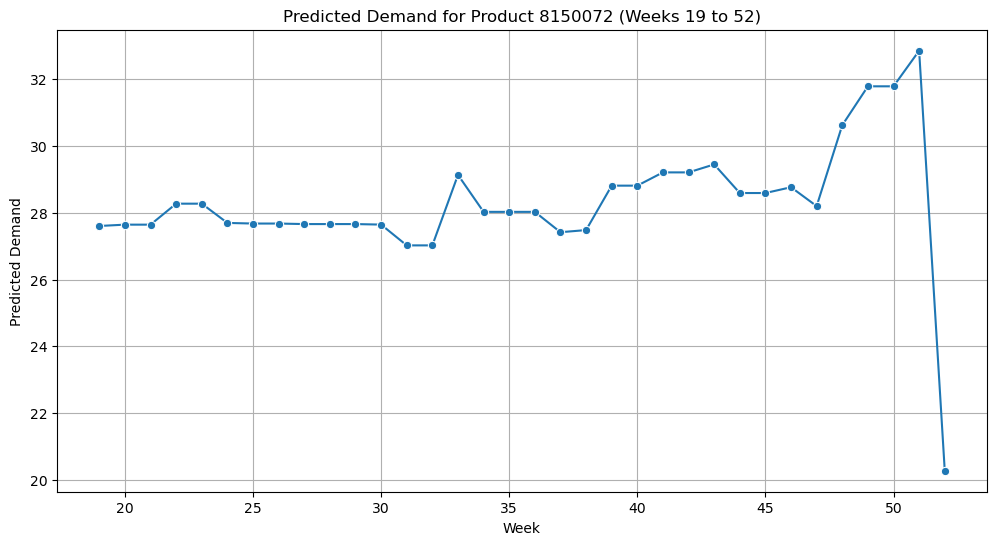

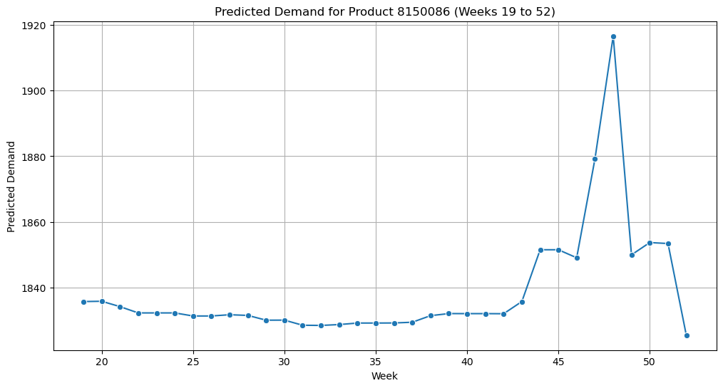

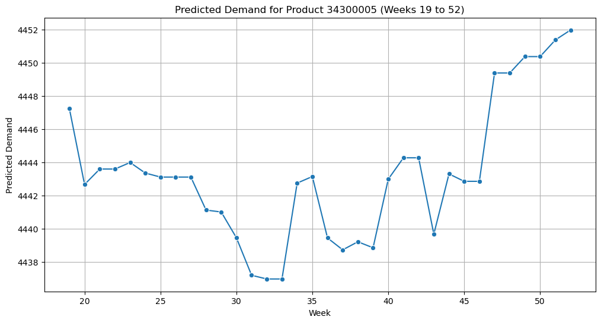

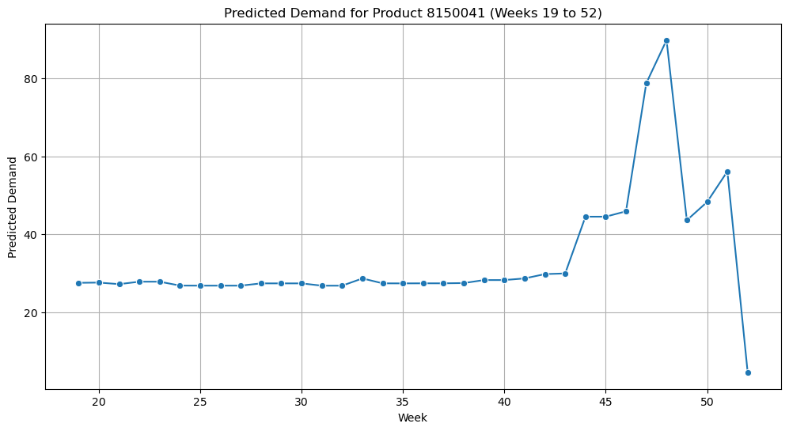

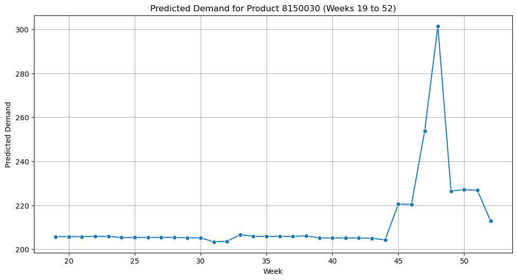

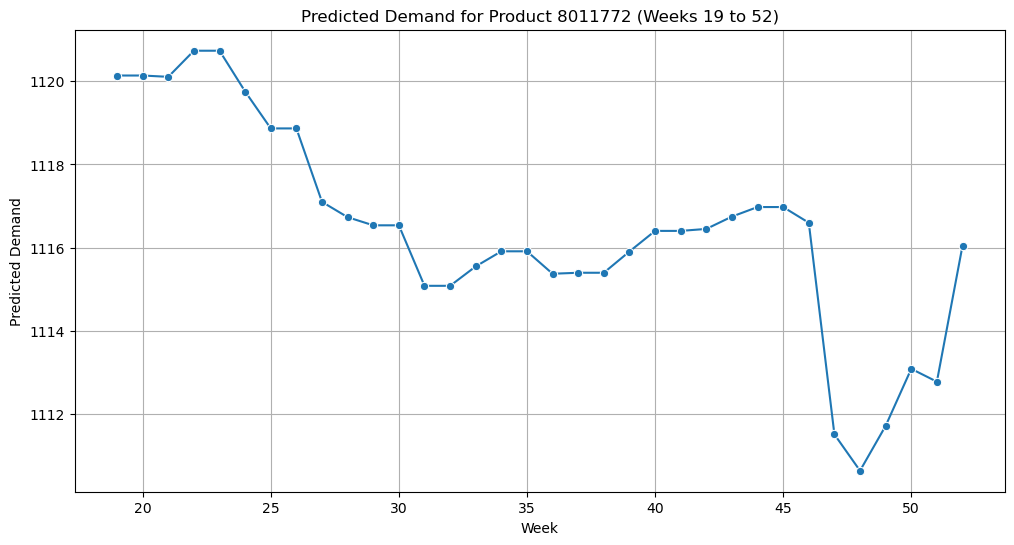

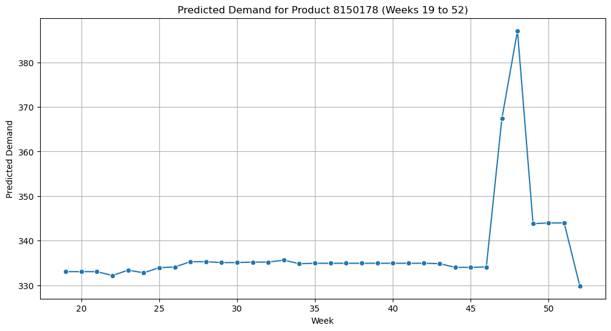

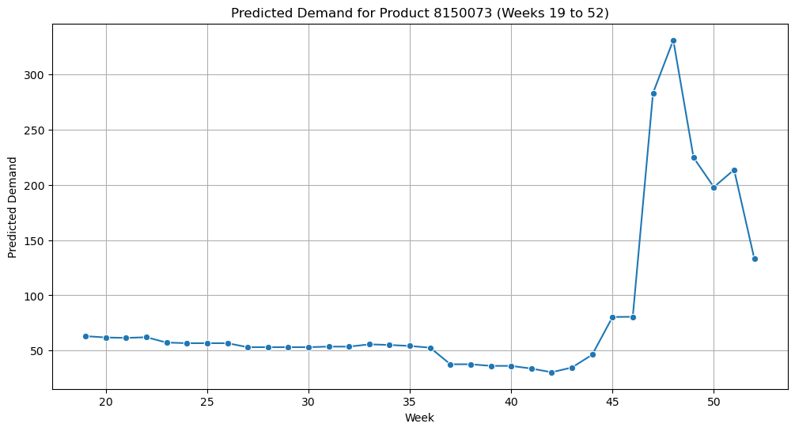

[16 more figures not shown]

```python
import matplotlib.pyplot as plt
import seaborn as sns

# Create line graphs for each product
for product_id in top_10_corp_item_cd:
    product_data = future_predictions[future_predictions['corp_item_cd'] == product_id]

    plt.figure(figsize=(12, 6))
    sns.lineplot(x='Week', y='Predicted_Demand', data=product_data, marker='o')
    plt.title(f'Predicted Demand for Product {product_id} (Weeks 19 to 52)')
    plt.xlabel('Week')
    plt.ylabel('Predicted Demand')
    plt.grid(True)
    plt.show()
```

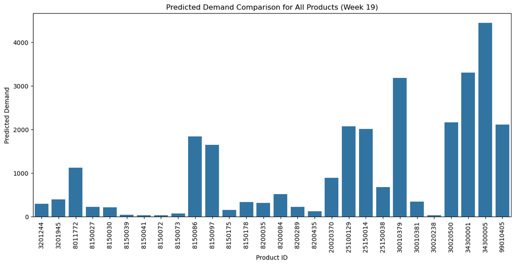

```python
# Compare all products' demand for a specific week (e.g., Week 19)
week_19_data = future_predictions[future_predictions['Week'] == 19]

plt.figure(figsize=(14, 6))
sns.barplot(x='corp_item_cd', y='Predicted_Demand', data=week_19_data)
plt.title('Predicted Demand Comparison for All Products (Week 19)')
plt.xlabel('Product ID')
plt.ylabel('Predicted Demand')
plt.xticks(rotation=90)
plt.show()
```

[figure not shown]

```python
# Calculate total predicted demand for each product
total_demand_per_product = future_predictions.groupby('corp_item_cd')['Predicted_Demand'].sum().reset_index()
total_demand_per_product = total_demand_per_product.sort_values(by='Predicted_Demand', ascending=False)

# Calculate cumulative percentage
total_demand_per_product['Cumulative Demand'] = total_demand_per_product['Predicted_Demand'].cumsum()
total_demand_per_product['Cumulative Percentage'] = (total_demand_per_product['Cumulative Demand'] / total_demand_per_product['Predicted_Demand'].sum()) * 100

# Plot Pareto chart
fig, ax1 = plt.subplots(figsize=(14, 6))

ax1.bar(total_demand_per_product['corp_item_cd'], total_demand_per_product['Predicted_Demand'], color='C0')
ax1.set_xlabel('Product ID')
ax1.set_ylabel('Predicted Demand', color='C0')
ax1.tick_params(axis='y', labelcolor='C0')

ax2 = ax1.twinx()
ax2.plot(total_demand_per_product['corp_item_cd'], total_demand_per_product['Cumulative Percentage'], color='C1', marker='D')
ax2.set_ylabel('Cumulative Percentage', color='C1')
ax2.tick_params(axis='y', labelcolor='C1')
ax2.axhline(80, color='red', linestyle='--')

plt.title('Pareto Analysis of Predicted Demand for Top 10 Products (Weeks 19 to 52)')
plt.show()
```

```python
import matplotlib.pyplot as plt
import seaborn as sns
import os

# Create a directory to save the graphs if it doesn't exist
output_dir = "Graphs"
os.makedirs(output_dir, exist_ok=True)

# Create line graphs for each product
for product_id in top_10_corp_item_cd:
    product_data = future_predictions[future_predictions['corp_item_cd'] == product_id]

    plt.figure(figsize=(12, 6))
    sns.lineplot(x='Week', y='Predicted_Demand', data=product_data, marker='o')
    plt.title(f'Predicted Demand for Product {product_id} (Weeks 19 to 52)')
    plt.xlabel('Week')
    plt.ylabel('Predicted Demand')
    plt.grid(True)

    # Save graph to file instead of displaying it
    plt.savefig(f"{output_dir}/Product_{product_id}_LineGraph.png", bbox_inches='tight')
    plt.close()  # Close the plot to avoid display
```

```python
week_19_data = future_predictions[future_predictions['Week'] == 19]

plt.figure(figsize=(14, 6))
sns.barplot(x='corp_item_cd', y='Predicted_Demand', data=week_19_data)
plt.title('Predicted Demand Comparison for All Products (Week 19)')
plt.xlabel('Product ID')
plt.ylabel('Predicted Demand')
plt.xticks(rotation=90)

# Save graph to file
plt.savefig(f"{output_dir}/Comparative_BarGraph_Week19.png", bbox_inches='tight')
plt.close()
```

```python
# Calculate total predicted demand for each product
total_demand_per_product = future_predictions.groupby('corp_item_cd')['Predicted_Demand'].sum().reset_index()
total_demand_per_product = total_demand_per_product.sort_values(by='Predicted_Demand', ascending=False)

# Calculate cumulative percentage
total_demand_per_product['Cumulative Demand'] = total_demand_per_product['Predicted_Demand'].cumsum()
total_demand_per_product['Cumulative Percentage'] = (total_demand_per_product['Cumulative Demand'] / total_demand_per_product['Predicted_Demand'].sum()) * 100

# Plot Pareto chart
fig, ax1 = plt.subplots(figsize=(14, 6))

ax1.bar(total_demand_per_product['corp_item_cd'], total_demand_per_product['Predicted_Demand'], color='C0')
ax1.set_xlabel('Product ID')
ax1.set_ylabel('Predicted Demand', color='C0')
ax1.tick_params(axis='y', labelcolor='C0')

ax2 = ax1.twinx()
ax2.plot(total_demand_per_product['corp_item_cd'], total_demand_per_product['Cumulative Percentage'], color='C1', marker='D')
ax2.set_ylabel('Cumulative Percentage', color='C1')
ax2.tick_params(axis='y', labelcolor='C1')
ax2.axhline(80, color='red', linestyle='--')

plt.title('Pareto Analysis of Predicted Demand for Top 10 Products (Weeks 19 to 52)')
plt.savefig(f"{output_dir}/Pareto_Chart.png", bbox_inches='tight')
plt.close()
```

# 📊 Product Demand Analysis and Recommendations

## Overview

This analysis covers the predicted demand for 28 products from Week 19 to Week 52. Based on the observed trends, appropriate actions are recommended for the company to optimize inventory management, marketing strategies, and operational planning.

## 🔍 Analysis & Recommendations

### 2. Product 8150097

- **Observation**: Stable demand with minor spikes during specific weeks.
- **Recommendation**: Ensure adequate inventory to cover peaks but avoid overstocking.

### 4. Product 8150027

- **Observation**: Demand fluctuates moderately with a noticeable peak around week 45.
- **Recommendation**: Increase inventory leading up to week 45 and adjust afterward to prevent overstock.

### 5. Product 8150072

- **Observation**: Consistent demand with occasional small peaks.
- **Recommendation**: Maintain inventory levels and monitor for significant deviations.

### 6. Product 8150086

- **Observation**: Demand generally consistent but shows a noticeable spike around week 45.
- **Recommendation**: Prepare inventory before week 45 to avoid stockouts during the peak.

### 7. Product 34300005

- **Observation**: Gradual increase in demand, particularly from week 30 onwards.
- **Recommendation**: Plan inventory increases to match the growing demand trend.

### 8. Product 8150041

- **Observation**: Stable demand with occasional peaks.
- **Recommendation**: Maintain consistent inventory and prepare for periodic demand increases.

### 9. Product 8150030

- **Observation**: Steady demand with a moderate peak around week 45.
- **Recommendation**: Ensure adequate inventory to meet demand peaks while avoiding overstocking.

### 10. Product 8011772

- **Observation**: Demand is consistent with minimal fluctuations.
- **Recommendation**: Maintain inventory levels with minor adjustments for rare peaks.

### 11. Product 8150178

- **Observation**: Consistent demand with noticeable peaks around week 45.
- **Recommendation**: Increase inventory ahead of the predicted peak period.

### 13. Product 20020370

- **Observation**: Gradual decline in demand with occasional peaks.
- **Recommendation**: Reduce inventory gradually while ensuring availability during peak periods.

### 14. Product 30020500

- **Observation**: Steady growth in demand with a sharp peak around week 45.
- **Recommendation**: Increase inventory ahead of peak demand and adjust thereafter.

### 15. Product 30010379

- **Observation**: Consistent demand with a sharp peak around week 45.
- **Recommendation**: Ensure adequate stock levels to meet peak demand before scaling down.

### 16. Product 25150014

- **Observation**: Steady demand with minor fluctuations and a sharp increase around week 45.
- **Recommendation**: Prepare inventory for anticipated peaks and adjust afterward to avoid overstocking.

### 17. Product 25150038

- **Observation**: Stable demand with a spike around week 45.
- **Recommendation**: Prepare inventory ahead of the peak and scale down afterward.

### 18. Product 30020238

- **Observation**: Consistent demand with periodic increases around week 45.
- **Recommendation**: Increase inventory as necessary to accommodate periodic peaks.

### 19. Product 30010381

- **Observation**: Steady demand with occasional spikes.
- **Recommendation**: Monitor demand patterns and adjust inventory accordingly.

### 20. Product 34300001

- **Observation**: Consistent demand with a slight upward trend over time.
- **Recommendation**: Gradually increase inventory to match the upward trend.

### 21. Product 25100129

- **Observation**: Relatively consistent demand with a spike around week 45.
- **Recommendation**: Prepare for demand spikes by adjusting inventory appropriately.

### 22. Product 99010405

- **Observation**: Gradual decline in demand with a sharp peak around week 45.
- **Recommendation**: Plan inventory for anticipated peaks and gradually reduce post-peak.

### 23. Product 8200289

- **Observation**: Demand is stable with occasional spikes, particularly around week 45.
- **Recommendation**: Increase inventory to meet spikes but reduce after the peak.

### 24. Product 8200435

- **Observation**: Steady demand with moderate peaks at specific intervals.
- **Recommendation**: Prepare inventory to meet periodic peaks and avoid overstocking.

### 25. Product 8200035

- **Observation**: Consistent demand with a notable peak around week 45.
- **Recommendation**: Prepare for anticipated demand spikes by adjusting inventory.

### 26. Product 3201945

- **Observation**: Steady demand with occasional spikes.
- **Recommendation**: Adjust inventory based on demand trends and ensure availability during peaks.

### 27. Product 3201244

- **Observation**: Consistent demand with minimal fluctuations.
- **Recommendation**: Maintain steady inventory levels with minor adjustments as needed.

### 28. Product 8200084

- **Observation**: Demand shows moderate fluctuations with a noticeable peak around week 45.
- **Recommendation**: Ensure sufficient inventory to cover predicted spikes and monitor for deviations.

```python
future_predictions.to_csv('predicted_demand.csv', index=False)
```

```python
predicted_demand = pd.read_csv('predicted_demand.csv')
```

```python
from pulp import LpMaximize, LpMinimize, LpProblem, LpStatus, LpVariable, lpSum, value
import pandas as pd

# Load predicted demand data (replace with your actual file name)
predicted_demand = pd.read_csv('predicted_demand.csv')

# Define unique products
products = predicted_demand['corp_item_cd'].unique()

# Define weeks
weeks = list(range(19, 53))

# Inventory parameters (Example values, adjust as needed)
holding_cost = 0.5  # Per unit per week
ordering_cost = 50  # Per order
safety_stock = 100  # Example safety stock level for each product

# Initialize the problem
model_pulp = LpProblem("Inventory_Optimization_PuLP", LpMinimize)

# Decision Variables
Q = LpVariable.dicts("Order_Quantity", [(p, w) for p in products for w in weeks], lowBound=0, cat='Continuous')
I = LpVariable.dicts("Inventory", [(p, w) for p in products for w in weeks], lowBound=0, cat='Continuous')

# Objective Function: Minimize Holding and Ordering Costs
model_pulp += lpSum([
    holding_cost * I[(p, w)] + ordering_cost * Q[(p, w)]
    for p in products for w in weeks
])

# Constraints
for p in products:
    for w in weeks:
        # Predicted demand for the product in the given week
        predicted_demand_value = predicted_demand[(predicted_demand['corp_item_cd'] == p) & (predicted_demand['Week'] == w)]['Predicted_Demand'].values[0]

        if w == 19:
            # Initialize inventory with safety stock for the first week
            model_pulp += I[(p, w)] == safety_stock + Q[(p, w)] - predicted_demand_value
        else:
            # Inventory balance equation
            model_pulp += I[(p, w)] == I[(p, w-1)] + Q[(p, w)] - predicted_demand_value

# Solve the model
model_pulp.solve()

# Display results
results_pulp = pd.DataFrame([(p, w, Q[(p, w)].varValue, I[(p, w)].varValue) for p in products for w in weeks],
                            columns=['Product', 'Week', 'Order_Quantity', 'Inventory'])

print(results_pulp)
```

```
     Product  Week  Order_Quantity  Inventory
0    8150175    19       47.581637        0.0
1    8150175    20      147.581640        0.0
2    8150175    21      148.606230        0.0
3    8150175    22      154.703830        0.0
4    8150175    23      151.693580        0.0
..       ...   ...             ...        ...
947  8200084    48      512.480840        0.0
948  8200084    49      512.118810        0.0
949  8200084    50      512.224720        0.0
950  8200084    51      512.224720        0.0
951  8200084    52      511.320110        0.0

[952 rows x 4 columns]
```

```python
from gurobipy import Model, GRB
import pandas as pd

# Load predicted demand data (replace with your actual file name)
predicted_demand = pd.read_csv('predicted_demand.csv')

# Define unique products
products = predicted_demand['corp_item_cd'].unique()

# Define weeks
weeks = list(range(19, 53))

# Inventory parameters (Example values, adjust as needed)
holding_cost = 0.5  # Per unit per week
ordering_cost = 50  # Per order
safety_stock = 100  # Example safety stock level for each product

# Initialize the model
model_gurobi = Model("Inventory_Optimization_Gurobi")
model_gurobi.setParam('OutputFlag', 0)

# Decision Variables
Q = model_gurobi.addVars(products, weeks, name="Order_Quantity", lb=0)
I = model_gurobi.addVars(products, weeks, name="Inventory", lb=0)

# Objective Function
model_gurobi.setObjective(
    sum(holding_cost * I[p, w] + ordering_cost * Q[p, w] for p in products for w in weeks),
    GRB.MINIMIZE
)

# Constraints
for p in products:
    for w in weeks:
        # Predicted demand for the product in the given week
        predicted_demand_value = predicted_demand[(predicted_demand['corp_item_cd'] == p) & (predicted_demand['Week'] == w)]['Predicted_Demand'].values[0]

        if w == 19:
            # Initialize inventory with safety stock for the first week
            model_gurobi.addConstr(I[p, w] == safety_stock + Q[p, w] - predicted_demand_value)
        else:
            # Inventory balance equation
            model_gurobi.addConstr(I[p, w] == I[p, w-1] + Q[p, w] - predicted_demand_value)

# Optimize the model
model_gurobi.optimize()

# Display results
results_gurobi = pd.DataFrame([(p, w, Q[p, w].x, I[p, w].x) for p in products for w in weeks],
                              columns=['Product', 'Week', 'Order_Quantity', 'Inventory'])

print(results_gurobi)
```

```
Restricted license - for non-production use only - expires 2026-11-23
     Product  Week  Order_Quantity  Inventory
0    8150175    19       47.581637        0.0
1    8150175    20      147.581637        0.0
2    8150175    21      148.606235        0.0
3    8150175    22      154.703834        0.0
4    8150175    23      151.693580        0.0
..       ...   ...             ...        ...
947  8200084    48      512.480840        0.0
948  8200084    49      512.118813        0.0
949  8200084    50      512.224717        0.0
950  8200084    51      512.224717        0.0
951  8200084    52      511.320107        0.0

[952 rows x 4 columns]
```

```python
pip install pulp
```

[output not shown]

```python
pip install gurobipy
```

[output not shown]

```python
from pulp import LpMinimize, LpProblem, LpVariable, lpSum, value
import pandas as pd

# Load predicted demand data
predicted_demand = pd.read_csv('predicted_demand.csv')

# Define unique products
products = predicted_demand['corp_item_cd'].unique()

# Define weeks
weeks = list(range(19, 53))

# Inventory parameters (Example values, adjust as needed)
holding_cost = 0.5  # Per unit per week
ordering_cost = 50  # Per order
initial_inventory = 200  # Starting inventory level for each product (Example value)

# Initialize the problem
model_pulp = LpProblem("Inventory_Optimization_PuLP", LpMinimize)

# Decision Variables
Q = LpVariable.dicts("Order_Quantity", [(p, w) for p in products for w in weeks], lowBound=0, cat='Continuous')
I = LpVariable.dicts("Inventory", [(p, w) for p in products for w in weeks], lowBound=0, cat='Continuous')

# Objective Function: Minimize Holding and Ordering Costs
model_pulp += lpSum([
    holding_cost * I[(p, w)] + ordering_cost * Q[(p, w)]
    for p in products for w in weeks
])

# Constraints
for p in products:
    for w in weeks:
        predicted_demand_value = predicted_demand[(predicted_demand['corp_item_cd'] == p) & (predicted_demand['Week'] == w)]['Predicted_Demand'].values[0]

        if w == 19:
            # Initialize inventory with initial inventory for the first week
            model_pulp += I[(p, w)] == initial_inventory + Q[(p, w)] - predicted_demand_value
        else:
            # Inventory balance equation - Inventory carries over from previous week
            model_pulp += I[(p, w)] == I[(p, w-1)] + Q[(p, w)] - predicted_demand_value

# Solve the model
model_pulp.solve()

# Extract results
results_pulp = pd.DataFrame([(p, w, Q[(p, w)].varValue, I[(p, w)].varValue) for p in products for w in weeks],
                            columns=['Product', 'Week', 'Order_Quantity', 'Inventory'])

print(results_pulp)
```

```
     Product  Week  Order_Quantity  Inventory
0    8150175    19        0.000000  52.418363
1    8150175    20       95.163273   0.000000
2    8150175    21      148.606230   0.000000
3    8150175    22      154.703830   0.000000
4    8150175    23      151.693580   0.000000
..       ...   ...             ...        ...
947  8200084    48      512.480840   0.000000
948  8200084    49      512.118810   0.000000
949  8200084    50      512.224720   0.000000
950  8200084    51      512.224720   0.000000
951  8200084    52      511.320110   0.000000

[952 rows x 4 columns]
```

```python
from pulp import LpMinimize, LpProblem, LpVariable, lpSum, value
import pandas as pd

# Load predicted demand data
predicted_demand = pd.read_csv('predicted_demand.csv')

# Define unique products
products = predicted_demand['corp_item_cd'].unique()

# Define weeks
weeks = list(range(19, 53))

# Inventory parameters (Example values, adjust as needed)
holding_cost = 0.5  # Per unit per week
ordering_cost = 50  # Per order
initial_inventory = 500  # Adjusted Initial inventory level
safety_stock = 100  # Minimum stock to maintain for each product

# Initialize the problem
model_pulp = LpProblem("Inventory_Optimization_PuLP", LpMinimize)

# Decision Variables
Q = LpVariable.dicts("Order_Quantity", [(p, w) for p in products for w in weeks], lowBound=0, cat='Continuous')
I = LpVariable.dicts("Inventory", [(p, w) for p in products for w in weeks], lowBound=0, cat='Continuous')

# Objective Function: Minimize Holding and Ordering Costs
model_pulp += lpSum([
    holding_cost * I[(p, w)] + ordering_cost * Q[(p, w)]
    for p in products for w in weeks
])

# Constraints
for p in products:
    for w in weeks:
        predicted_demand_value = predicted_demand[(predicted_demand['corp_item_cd'] == p) & (predicted_demand['Week'] == w)]['Predicted_Demand'].values[0]

        if w == 19:
            # Initialize inventory with initial inventory for the first week
            model_pulp += I[(p, w)] == initial_inventory + Q[(p, w)] - predicted_demand_value

            # Ensure safety stock is maintained
            model_pulp += I[(p, w)] >= safety_stock

        else:
            # Inventory balance equation - Inventory carries over from previous week
            model_pulp += I[(p, w)] == I[(p, w-1)] + Q[(p, w)] - predicted_demand_value

            # Ensure safety stock is maintained
            model_pulp += I[(p, w)] >= safety_stock

# Solve the model
model_pulp.solve()

# Extract results
results_pulp = pd.DataFrame([(p, w, Q[(p, w)].varValue, I[(p, w)].varValue) for p in products for w in weeks],
                            columns=['Product', 'Week', 'Order_Quantity', 'Inventory'])

print(results_pulp)
```

```
     Product  Week  Order_Quantity  Inventory
0    8150175    19        0.000000  352.41836
1    8150175    20        0.000000  204.83673
2    8150175    21       43.769508  100.00000
3    8150175    22      154.703830  100.00000
4    8150175    23      151.693580  100.00000
..       ...   ...             ...        ...
947  8200084    48      512.480840  100.00000
948  8200084    49      512.118810  100.00000
949  8200084    50      512.224720  100.00000
950  8200084    51      512.224720  100.00000
951  8200084    52      511.320110  100.00000

[952 rows x 4 columns]
```

```python
from pulp import LpMinimize, LpProblem, LpVariable, lpSum, value
import pandas as pd

# Load your combined file with historical data and predictions
data = pd.read_csv('merged_left_v3.csv')  # Ensure the file is correctly loaded

# Filter data for relevant years (2023, 2024) for historical analysis
historical_data = data[(data['year_dem'].isin([2023, 2024]))]

# Define unique products (top 10)
products = data['corp_item_cd'].unique()

# Define weeks (19 to 52)
weeks = list(range(19, 53))

# Inventory parameters (you can adjust these)
holding_cost = 0.5  # Per unit per week
ordering_cost = 50  # Per order
stockout_penalty = 5  # Penalty per unit of unmet demand

# Initialize the optimization model
model = LpProblem("Inventory_Optimization", LpMinimize)

# Decision Variables
Q = LpVariable.dicts("Order_Quantity", [(p, w) for p in products for w in weeks], lowBound=0, cat='Continuous')
I = LpVariable.dicts("Inventory", [(p, w) for p in products for w in weeks], lowBound=0, cat='Continuous')
U = LpVariable.dicts("Unmet_Demand", [(p, w) for p in products for w in weeks], lowBound=0, cat='Continuous')  # Unmet demand

# Objective Function: Minimize holding, ordering, and stockout penalty costs
model += lpSum([
    holding_cost * I[(p, w)] + ordering_cost * Q[(p, w)] + stockout_penalty * U[(p, w)]
    for p in products for w in weeks
])

# Constraints
for p in products:
    # Get historical `on_hand` data for 2023 & 2024 for each product
    product_data = historical_data[historical_data['corp_item_cd'] == p]

    # Drop NaN values before calculating the mean
baseline_inventory = product_data['on_hand'].dropna().mean()

# If the result is NaN (because all values were NaN), set a default value
if pd.isna(baseline_inventory):
    baseline_inventory = 0  # or some other sensible default value, e.g., average across all products


    for w in weeks:
        # Get the predicted demand for this product and week
        try:
            predicted_demand_value = data[(data['corp_item_cd'] == p) & (data['week_dem'] == w) & (data['year_dem'] == 2025)]['valid_demand_qty'].values[0]
        except IndexError:
            predicted_demand_value = 0  # In case no demand prediction is available for that week

        if w == 19:
            # Starting inventory is based on historical average
            model += I[(p, w)] == baseline_inventory + Q[(p, w)] - predicted_demand_value + U[(p, w)]
        else:
            # Inventory balance equation
            model += I[(p, w)] == I[(p, w-1)] + Q[(p, w)] - predicted_demand_value + U[(p, w)]

        # Ensure unmet demand is correctly calculated, only for weeks after week 19
        if w > 19:
            model += U[(p, w)] >= predicted_demand_value - (I[(p, w-1)] + Q[(p, w)])

# Solve the model
model.solve()

# Extract results
results = pd.DataFrame([(p, w, Q[(p, w)].varValue, I[(p, w)].varValue, U[(p, w)].varValue)
                        for p in products for w in weeks],
                       columns=['Product', 'Week', 'Order_Quantity', 'Inventory', 'Unmet_Demand'])

print(results)
```

```
         Product  Week  Order_Quantity  Inventory  Unmet_Demand
0       88800922    19             0.0        0.0           0.0
1       88800922    20             0.0        0.0           0.0
2       88800922    21             0.0        0.0           0.0
3       88800922    22             0.0        0.0           0.0
4       88800922    23             0.0        0.0           0.0
...          ...   ...             ...        ...           ...
600163  79502788    48             0.0        0.0           0.0
600164  79502788    49             0.0        0.0           0.0
600165  79502788    50             0.0        0.0           0.0
600166  79502788    51             0.0        0.0           0.0
600167  79502788    52             0.0        0.0           0.0

[600168 rows x 5 columns]
```

```python
import pandas as pd

# Load your main dataset
main_data = pd.read_csv('merged_left_v3.csv')

# Load your predicted demand dataset
predicted_demand = pd.read_csv('predicted_demand.csv')

# Filter the main data for years 2023 and 2024 only
filtered_data = main_data[(main_data['year_inv'].isin([2023, 2024]))]

# Calculate baseline inventory (average of 'on_hand' for weeks 19-52 for each product)
baseline_inventory = filtered_data[filtered_data['week_inv'].between(19, 52)] \
    .groupby('corp_item_cd')['on_hand'].mean().reset_index()
baseline_inventory.columns = ['corp_item_cd', 'baseline_inventory']

# Merge baseline inventory with your predicted demand data
merged_data = predicted_demand.merge(baseline_inventory, on='corp_item_cd', how='left')

# Displaying the merged data to verify
print(merged_data.head())
```

```
   corp_item_cd  Week  Predicted_Demand  baseline_inventory
0       8150175    19        147.581637         1136.352941
1       8150175    20        147.581637         1136.352941
2       8150175    21        148.606235         1136.352941
3       8150175    22        154.703834         1136.352941
4       8150175    23        151.693580         1136.352941
```

```python
from pulp import LpMinimize, LpProblem, LpVariable, lpSum, value
import pandas as pd

# Load the original dataset
data = pd.read_csv('merged_left_v3.csv')

# Filter for the top 10 products
top_10_products = [8150175, 8150097, 8150039, 8150027, 8150072, 8200084, 3201244, 3201945, 8011772, 8150030]
filtered_data = data[data['corp_item_cd'].isin(top_10_products)]

# Calculate baseline inventory for each product based on the historical average from 2023 and 2024
baseline_inventory = filtered_data.groupby('corp_item_cd')['on_hand'].mean().to_dict()

# Define unique products
products = filtered_data['corp_item_cd'].unique()

# Define the model
model = LpProblem("Inventory_Optimization", LpMinimize)

# Create decision variables
Q = {(p, w): LpVariable(f"Order_{p}_{w}", lowBound=0, cat='Continuous') for p in products for w in range(19, 53)}
I = {(p, w): LpVariable(f"Inventory_{p}_{w}", lowBound=0, cat='Continuous') for p in products for w in range(19, 53)}
U = {(p, w): LpVariable(f"Unmet_Demand_{p}_{w}", lowBound=0, cat='Continuous') for p in products for w in range(19, 53)}

# Define the cost parameters
holding_cost = 0.1  # Example holding cost per unit per week
penalty_cost = 2.0  # Example unmet demand penalty cost per unit

# Add objective function (Minimize total cost)
model += lpSum([
    holding_cost * I[(p, w)] + penalty_cost * U[(p, w)]
    for p in products
    for w in range(19, 53)
])

# Add constraints
for p in products:
    product_data = filtered_data[filtered_data['corp_item_cd'] == p]
    baseline_inv = baseline_inventory.get(p, 0)

    for w in range(19, 53):
        predicted_demand_value = product_data[product_data['week_dem'] == w]['valid_demand_qty'].sum()

        if w == 19:
            # Starting inventory is based on the calculated baseline inventory
            model += I[(p, w)] == baseline_inv + Q[(p, w)] - predicted_demand_value + U[(p, w)]
        else:
            previous_week = w - 1
            model += I[(p, w)] == I[(p, previous_week)] + Q[(p, w)] - predicted_demand_value + U[(p, w)]

        # Ensure unmet demand is correctly calculated
        model += U[(p, w)] >= predicted_demand_value - (I[(p, w)] + Q[(p, w)])

# Solve the model
model.solve()

# Extract results
results = []
for p in products:
    for w in range(19, 53):
        results.append([
            p,
            w,
            value(Q[(p, w)]),
            value(I[(p, w)]),
            value(U[(p, w)])
        ])

# Convert results to a DataFrame
results_df = pd.DataFrame(results, columns=['corp_item_cd', 'Week', 'Order_Quantity', 'Inventory', 'Unmet_Demand'])

# Display the results
print(results_df)
```

```
     corp_item_cd  Week  Order_Quantity   Inventory  Unmet_Demand
0         8150030    19        0.000000  539.614040           0.0
1         8150030    20       45.192982  269.807020           0.0
2         8150030    21      163.096490  134.903510           0.0
3         8150030    22      243.548250   67.451754           0.0
4         8150030    23      244.274120   33.725877           0.0
..            ...   ...             ...         ...           ...
335       8150072    48        0.000000  706.400000           0.0
336       8150072    49        0.000000  706.400000           0.0
337       8150072    50        0.000000  706.400000           0.0
338       8150072    51        0.000000  658.400000           0.0
339       8150072    52        0.000000  546.400000           0.0

[340 rows x 5 columns]
```

```python
from pulp import LpProblem, LpMinimize, LpVariable, lpSum, value
import pandas as pd

# Load predicted demand data (replace with your actual dataframe variable name)
predicted_demand = pd.read_csv('merged_left_v3.csv')

# Define unique products
products = predicted_demand['corp_item_cd'].unique()
weeks = list(range(19, 53))  # Weeks from 19 to 52

# Initialize the model
model = LpProblem("Inventory_Optimization", LpMinimize)

# Define decision variables
Q = LpVariable.dicts("Order_Quantity", [(p, w) for p in products for w in weeks], lowBound=0)
I = LpVariable.dicts("Inventory", [(p, w) for p in products for w in weeks], lowBound=0)
U = LpVariable.dicts("Unmet_Demand", [(p, w) for p in products for w in weeks], lowBound=0)

# Create a dictionary to store baseline inventory values
baseline_inventory_dict = {}

# Calculate baseline inventory for each product based on the average on_hand for weeks before week 19
for product_id in products:
    product_data = predicted_demand[(predicted_demand['corp_item_cd'] == product_id) & (predicted_demand['week_inv'] < 19)]

    if not product_data.empty and 'on_hand' in product_data.columns:
        baseline_inventory = product_data['on_hand'].dropna().mean()
        baseline_inventory_dict[product_id] = baseline_inventory
    else:
        baseline_inventory_dict[product_id] = 0  # Set to 0 if no historical data is available

# Add objective function: Minimize total unmet demand
model += lpSum([U[(p, w)] for p in products for w in weeks])

# Add constraints for inventory balance and unmet demand calculation
for p in products:
    for w in weeks:
        # Get predicted demand and shipped quantity for the current product and week
        predicted_demand_value = predicted_demand.loc[
            (predicted_demand['corp_item_cd'] == p) & (predicted_demand['week_dem'] == w),
            'valid_demand_qty'
        ].sum()

        shipped_value = predicted_demand.loc[
            (predicted_demand['corp_item_cd'] == p) & (predicted_demand['week_dem'] == w),
            'whse_quantity_shipped'
        ].sum()

        if w == 19:
            # Starting inventory is based on baseline inventory
            model += I[(p, w)] == baseline_inventory_dict[p] + Q[(p, w)] - shipped_value + U[(p, w)]
            model += U[(p, w)] >= predicted_demand_value - (baseline_inventory_dict[p] + Q[(p, w)])
        else:
            # Inventory balance equation
            model += I[(p, w)] == I[(p, w-1)] + Q[(p, w)] - shipped_value + U[(p, w)]
            model += U[(p, w)] >= predicted_demand_value - (I[(p, w-1)] + Q[(p, w)])

# Solve the model
model.solve()

# Collect results
results = []
for p in products:
    for w in weeks:
        results.append([
            p, w,
            value(Q[(p, w)]),
            value(I[(p, w)]),
            value(U[(p, w)])
        ])

# Convert results to DataFrame
results_df = pd.DataFrame(results, columns=['corp_item_cd', 'Week', 'Order_Quantity', 'Inventory', 'Unmet_Demand'])

# Display the first few rows of the results
print(results_df.head())
```

```
   corp_item_cd  Week  Order_Quantity  Inventory  Unmet_Demand
0      88800922    19       21.295455        0.0           0.0
1      88800922    20     1447.000000      960.0           0.0
2      88800922    21        0.000000      442.0           0.0
3      88800922    22        0.000000        0.0           0.0
4      88800922    23      957.000000      501.0           0.0
```

```python
import pandas as pd
import matplotlib.pyplot as plt
import os

# Load your original dataset
data = pd.read_csv('merged_left_v3.csv')

# Check if required columns exist
required_columns = ['corp_item_cd', 'valid_demand_qty', 'on_hand', 'week_dem', 'year_dem']
missing_columns = [col for col in required_columns if col not in data.columns]
if missing_columns:
    raise ValueError(f"The following required columns are missing from your dataset: {missing_columns}")

# Convert 'year_dem' and 'week_dem' to a single 'Week' column for easier plotting
data['Week'] = data['year_dem'].astype(str) + '_' + data['week_dem'].astype(str)

# Filter for the top 10 products
top_10_products = data['corp_item_cd'].value_counts().head(10).index.tolist()
top_10_data = data[data['corp_item_cd'].isin(top_10_products)]

# Create a directory to save the plots
output_dir = 'visualization_results'
os.makedirs(output_dir, exist_ok=True)

# Generate plots for each of the top 10 products
for product in top_10_products:
    product_data = top_10_data[top_10_data['corp_item_cd'] == product]

    plt.figure(figsize=(14, 6))
    plt.plot(product_data['Week'], product_data['valid_demand_qty'], label='Predicted Demand', marker='o')
    plt.plot(product_data['Week'], product_data['on_hand'], label='On Hand Inventory', marker='x')
    plt.title(f'Predicted Demand vs. On Hand Inventory for Product {product}')
    plt.xlabel('Week')
    plt.ylabel('Quantity')
    plt.legend()
    plt.xticks(rotation=45)
    plt.tight_layout()
    plt.grid(True)

    # Save plot
    plt.savefig(f'{output_dir}/Product_{product}_Demand_vs_Inventory.png')
    plt.close()
```

```python
for p in products:
    product_data = data[data['corp_item_cd'] == p]

    for w in weeks:
        # Retrieve predicted demand
        predicted_demand = product_data.loc[product_data['week_dem'] == w, 'valid_demand_qty'].sum()

        # Skip if predicted demand is NaN or inf
        if pd.isna(predicted_demand) or not np.isfinite(predicted_demand):
            continue

        # Retrieve shipped quantity
        shipped_quantity = product_data.loc[product_data['week_dem'] == w, 'whse_quantity_shipped'].sum()

        # Skip if shipped quantity is NaN or inf
        if pd.isna(shipped_quantity) or not np.isfinite(shipped_quantity):
            continue

        if w == 19:
            initial_inventory = baseline_inventory_dict.get(p, 0)

            # Skip if initial inventory is NaN or inf
            if pd.isna(initial_inventory) or not np.isfinite(initial_inventory):
                continue

            # Inventory balance equation for Week 19
            model += I[(p, w)] == initial_inventory + Q[(p, w)] - predicted_demand + shipped_quantity

        else:
            # Inventory balance equation for subsequent weeks
            model += I[(p, w)] == I[(p, w - 1)] + Q[(p, w)] - predicted_demand + shipped_quantity

        # Ensure unmet demand is calculated correctly
        if w == 19:
            if np.isfinite(baseline_inventory_dict.get(p, 0)):
                model += U[(p, w)] >= predicted_demand - (float(baseline_inventory_dict.get(p, 0)) + Q[(p, w)])
        else:
            model += U[(p, w)] >= predicted_demand - (I[(p, w - 1)] + Q[(p, w)])
```

```python
import pandas as pd

# Load the dataset
data = pd.read_csv('merged_left_v3.csv')

# Display all available column names
print("Available Columns:\n", data.columns.tolist())
```

[output not shown]

```python
import pandas as pd

# Load your predicted demand dataset
predicted_demand = pd.read_csv('predicted_demand.csv')

# Display column names
print("Columns in 'predicted_demand.csv':")
print(predicted_demand.columns.tolist())
```

```
Columns in 'predicted_demand.csv':
['corp_item_cd', 'Week', 'Predicted_Demand']
```

```python
import pandas as pd

# Load your original data and predicted demand data
original_data = pd.read_csv('merged_left_v3.csv')
predicted_demand = pd.read_csv('predicted_demand.csv')

# Rename the column 'Week' to 'week_dem' in the predicted demand DataFrame to match your original data
predicted_demand.rename(columns={'Week': 'week_dem'}, inplace=True)

# Merge the predicted demand data with the original dataset
merged_data = pd.merge(original_data, predicted_demand, on=['corp_item_cd', 'week_dem'], how='left')

# Save the merged file for further analysis
merged_data.to_csv('merged_with_predictions.csv', index=False)

print("Merged data successfully saved to 'merged_with_predictions.csv'")
```

```
Merged data successfully saved to 'merged_with_predictions.csv'
```

```python
import pandas as pd
import numpy as np

# Load your file
df = pd.read_csv('Inventory_Plan_by_Product.csv')

# Constants
lead_time = 1  # weeks
z_value = 1.65  # for 95% service level

# Group by product
grouped = df.groupby('corp_item_cd')

# Build smarter inventory table
final_data = []

for product_id, group in grouped:
    group = group.sort_values(by='Week')
    for i in range(len(group)):
        week = group.iloc[i]['Week']
        predicted_demand = group.iloc[i]['Predicted_Demand']

        # Average demand and std deviation can be adjusted dynamically (e.g., rolling window)
        avg_demand = group['Average_Demand'].iloc[i]
        std_dev = group['Std_Deviation'].iloc[i]

        safety_stock = z_value * std_dev * np.sqrt(lead_time)
        reorder_point = avg_demand * lead_time + safety_stock
        recommended_inventory = predicted_demand + safety_stock  # Smarter alignment to actual demand

        final_data.append({
            'corp_item_cd': product_id,
            'Week': week,
            'Predicted_Demand': predicted_demand,
            'Average_Demand': avg_demand,
            'Std_Deviation': std_dev,
            'Safety_Stock': round(safety_stock, 2),
            'Reorder_Point': round(reorder_point, 2),
            'Recommended_Inventory_Level': round(recommended_inventory, 2)
        })

# Convert to DataFrame and save
final_df = pd.DataFrame(final_data)
final_df.to_csv('Smarter_Inventory_Recommendations.csv', index=False)
print("✅ Smarter inventory recommendations saved as 'Smarter_Inventory_Recommendations.csv'")
```

```
✅ Smarter inventory recommendations saved as 'Smarter_Inventory_Recommendations.csv'
```

```python
print(df.columns.tolist())
```

```
['Unnamed: 0', 'corp_item_cd', 'Week', 'Predicted_Demand', 'Average_Demand', 'Std_Deviation', 'Safety_Stock', 'Reorder_Point', 'Recommended_Inventory_Level']
```

```python
import pandas as pd

# Load the dataset
df = pd.read_csv('Inventory_Plan_by_Product.csv')

# Set your desired service level (Z-score)
z_value = 1.65  # For ~95% service level

# Calculate a dynamic Reorder Point for each row
df['Dynamic_Reorder_Point'] = df['Predicted_Demand'] + z_value * df['Std_Deviation']

# Save to a new file
df.to_csv('Inventory_with_Dynamic_ROP.csv', index=False)

print("✅ New file 'Inventory_with_Dynamic_ROP.csv' created with dynamic reorder points.")
```

```
✅ New file 'Inventory_with_Dynamic_ROP.csv' created with dynamic reorder points.
```